# Setting up the logbook simulator: a user guide

Henning Winker FAO Fisheries and Aquaculture Division, Assessment and Management Team (NFIFM) henning.winker@fao.org

`simulate_logbook()` generates the kind of logbook an analyst receives from a mixed demersal-pelagic fishery, together with the truth that is never in a real logbook: where and with which tactic each trip fished, which vessel type made it, and how the stocks really changed. This guide walks through the simulator layer by layer, explains the settings that matter for targeting, and shows the basic mechanics: what the principal components (PCs) and clusters of the catch composition pick up when we know the truth.

The standardisation of three species from this logbook is shown in *Standardising a realistic logbook: two worked examples*.

| Layer | What it does | Main settings |
| --- | --- | --- |
| Environment | shelf-to-slope depth, reef patches in sediment, SST gradient | `grid`, `shelf_depth`, `reef_share`, `reef_scale`, `sst_range` |
| Species | demersal: depth x substrate; pelagic: SST, depth and season | `species` (one row per species) |
| Tactics | gear catchability of each species | `tactics` (tactic x species) |
| Fleet | vessel types, home tactics and loyalty, entry and exit | `vessel_types`, `home`, `loyalty`, `entry_share`, `exit_share` |
| Behaviour | trips go where expected value is high | `price_periods`, `preference`, `closure` |
| Dynamics | Schaefer production, movement, monthly removals | `r`, `B0`, `B_start`, `dispersal` |
| Reporting | trip records, two-set trips, coarse positions, rounding, under-reporting, synonyms | `logbook` |

# 1. Settings

All settings are in one list. Change any element and pass the list to `simulate_logbook()`; `species`, `tactics`, `price`, `trips`, `closure`, `vessel_types`, `home` and `loyalty` are replaced as a whole, the others are merged with the defaults.

```r
s <- logbook_settings()
names(s)
```

```
##  [1] "n_years"           "start_year"        "grid"              "shelf_depth"
##  [5] "shelf_power"       "depth_sd"          "depth_scale"       "reef_share"
##  [9] "reef_scale"        "sst_range"         "sst_sd"            "sst_scale"
## [13] "species"           "tactics"           "q"                 "price_periods"
## [17] "price"             "vessel_types"      "home"              "loyalty"
## [21] "vessel_cv"         "entry_share"       "creep"             "exit_share"
## [25] "trips"             "trips_cv"          "effort_season_amp" "hours_mean"
## [29] "hours_cv"          "preference"        "closure"           "tweedie_power"
## [33] "tweedie_phi"       "logbook"
```

```r
knitr::kable(s$species[, c("species", "group", "habitat", "depth_mu", "reef",
                           "sediment", "sst_mu", "season_amp", "price")],
             row.names = FALSE)
```

| species | group | habitat | depth_mu | reef | sediment | sst_mu | season_amp | price |
| --- | --- | --- | --- | --- | --- | --- | --- | --- |
| Dentex dentex | demersal | shallow reef | 60 | 1.00 | 0.02 | NA | 0.0 | 12 |
| Pagellus erythrinus | demersal | shallow sediment | 50 | 0.05 | 1.00 | NA | 0.0 | 8 |
| Pagellus bogaraveo | demersal | deep reef | 350 | 1.00 | 0.02 | NA | 0.0 | 15 |
| Merluccius merluccius | demersal | deep sediment | 400 | 0.05 | 1.00 | NA | 0.0 | 5 |
| Conger conger | demersal | reef, all depths | 150 | 1.00 | 0.30 | NA | 0.0 | 3 |
| Phycis blennoides | demersal | deep, mixed | 500 | 0.50 | 1.00 | NA | 0.0 | 2 |
| Thunnus alalunga | pelagic | offshore | 700 | 1.00 | 1.00 | 18 | 0.7 | 6 |
| Coryphaena hippurus | pelagic | warm, offshore | 300 | 1.00 | 1.00 | 21 | 0.9 | 7 |
| Seriola dumerili | pelagic | coastal, reef-associated | 100 | 1.00 | 0.30 | 20 | 0.4 | 9 |
| Scomber colias | pelagic | coastal | 60 | 1.00 | 1.00 | 18 | 0.3 | 2 |

```r
sim <- simulate_logbook(s, seed = 1)
```

# 2. Environment

Depth increases offshore (to the right) with random bumps; reef patches are the highest values of a smooth random field; sea temperature increases from north (top, cool) to south (bottom, warm), as in the Southern Hemisphere.

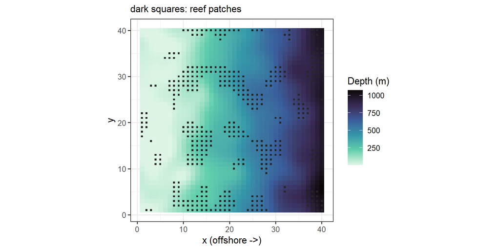

```r
sim$Plots$env
```

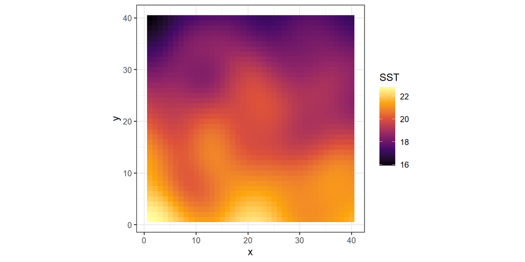

```r
sim$Plots$sst
```

**Reef patches.** `reef_share` is the share of cells that are reef and `reef_scale` the size (correlation length, in cells) of the patches.

- Lower `reef_share` or `reef_scale`: fewer or smaller, scattered patches. When patches are smaller than the reporting blocks (`logbook$obs_res`, 5 x 5 cells), reef and sediment trips share the same reported position, so a spatial term cannot separate them and only the catch composition can.
- Higher values: larger, connected reef areas that a spatial term on the reported positions can resolve.

The default (`reef_scale = 2.5`) deliberately makes patches about the size of a reporting block or smaller.

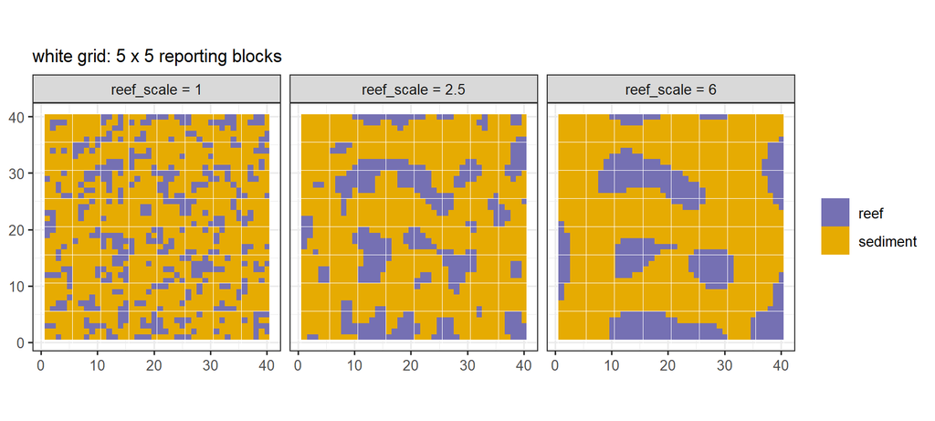

```r
reef_maps <- do.call(rbind, lapply(c(1, 2.5, 6), function(sc) {
  e <- simulate_logbook(modifyList(s, list(reef_scale = sc, n_years = 4)),
                        seed = 1, plots = FALSE)$env
  data.frame(e, reef_scale = paste("reef_scale =", sc))
}))
ggplot(reef_maps, aes(x = x, y = y, fill = substrate)) +
  geom_raster() + facet_wrap(~reef_scale) + coord_equal() +
  geom_vline(xintercept = seq(0.5, 40.5, by = 5), colour = "white", linewidth = 0.2) +
  geom_hline(yintercept = seq(0.5, 40.5, by = 5), colour = "white", linewidth = 0.2) +
  scale_fill_manual(values = c(reef = "#7570b3", sediment = "#e6ab02")) +
  labs(x = NULL, y = NULL, fill = NULL, subtitle = "white grid: 5 x 5 reporting blocks") +
  theme_bw()
```

# 3. Species and habitats

Demersal densities are the product of a depth preference (lognormal, `depth_mu`, `depth_cv`) and a substrate affinity (`reef`, `sediment`), so shallow reef, deep reef, shallow sediment and deep sediment arise as continuous gradients rather than sharp classes. Pelagic species follow sea temperature (`sst_mu`, `sst_sd`) and depth, and their availability changes over the year (`season_amp`, `season_peak`): dolphinfish and albacore are summer-autumn migrants.

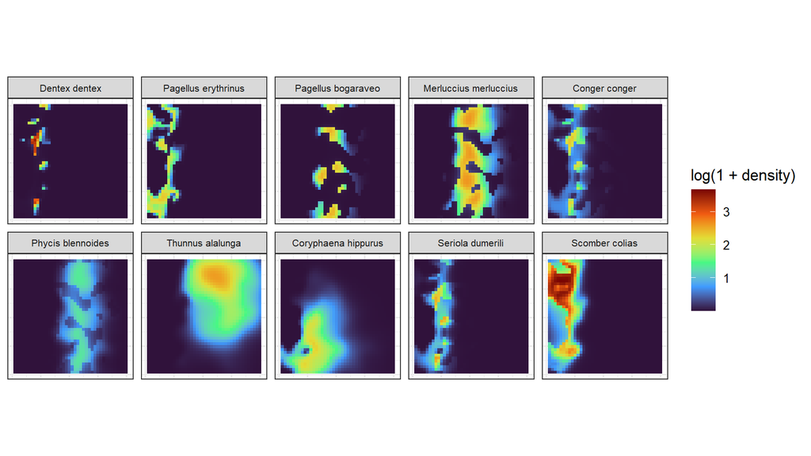

```r
sim$Plots$density
```

# 4. Tactics

A tactic is a gear used in a particular way. Its catchability of each species (`tactics`) is the gear selectivity; where the gear is used decides which species are available. The reef handline catches reef species, the bottom longline sediment species, and pelagic trolling the pelagic species, with some overlap (conger is caught by both bottom gears; amberjack by reef handline and trolling).

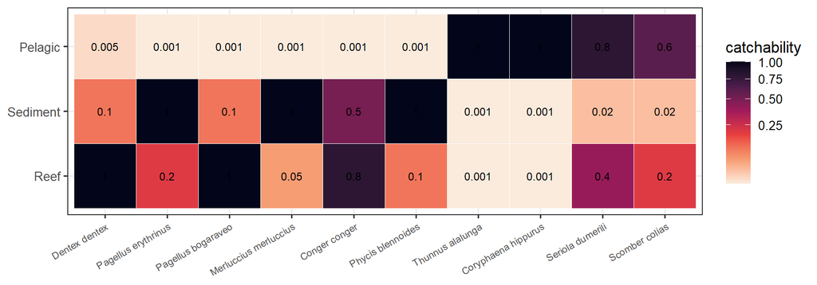

```r
q <- as.data.frame(as.table(s$tactics))
names(q) <- c("tactic", "species", "catchability")
ggplot(q, aes(x = species, y = tactic, fill = catchability)) +
  geom_tile(colour = "white") +
  geom_text(aes(label = catchability), size = 2.8) +
  scale_fill_viridis_c(option = "rocket", direction = -1, trans = "sqrt") +
  labs(x = NULL, y = NULL) + theme_bw() +
  theme(axis.text.x = element_text(angle = 30, hjust = 1, size = 7))
```

# 5. Fleet: specialists, mixed vessels and loyalty

Three vessel types (`vessel_types`) fish with different flexibility:

- **demersal specialists**: home tactics reef and sediment;
- **pelagic specialists**: home tactic pelagic;
- **mixed vessels**: no home preference.

Each month, a share `loyalty` of a specialist’s trips (default 0.8) is restricted to its home tactics; the remaining trips, and all trips of mixed vessels, choose among all tactics by expected value. Specialists therefore mostly stick to their gear but follow good opportunities, e.g. demersal boats trolling for dolphinfish in a good summer.

```r
s$home
```

```
## $demersal
## [1] "Reef"     "Sediment"
##
## $pelagic
## [1] "Pelagic"
##
## $mixed
## [1] "Reef"     "Sediment" "Pelagic"
```

```r
s$loyalty
```

```
## demersal  pelagic    mixed
##      0.8      0.8      0.0
```

```r
tr <- sim$trips
round(prop.table(table(type = tr$vessel_type, tactic = tr$tactic), 1), 2)
```

```
##           tactic
## type       Pelagic Reef Sediment
##   demersal    0.09 0.51     0.41
##   mixed       0.47 0.30     0.23
##   pelagic     0.89 0.06     0.05
```

```r
tapply(tr$loyal, tr$vessel_type, mean)
```

```
##  demersal     mixed   pelagic
## 0.7966311 0.0000000 0.8069538
```

Why it matters for standardisation: a specialist’s targeting barely changes, so a vessel effect absorbs it. Mixed vessels (and the non-loyal trips of specialists) switch tactics *within* the same vessel as prices change, which is the targeting that the catch composition has to capture.

- `loyalty = 1`: specialists never leave their home tactics.
- `loyalty = 0` for all types: every vessel behaves as a mixed vessel, the strongest targeting shifts.
- `preference`: how strongly trips concentrate on the most valuable cells and tactics (higher = more decisive skippers).

# 6. Prices, closure and fleet changes

Prices change in three periods: demersal species are expensive in 2000-2007, pelagic species boom in 2008-2015, then prices are neutral. From 2016 the bottom longline is banned deeper than 300 m and effort is cut by 20%. Some vessels enter later (and are more efficient, `creep`), others leave.

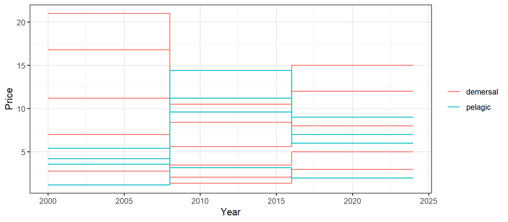

```r
sim$Plots$prices
```

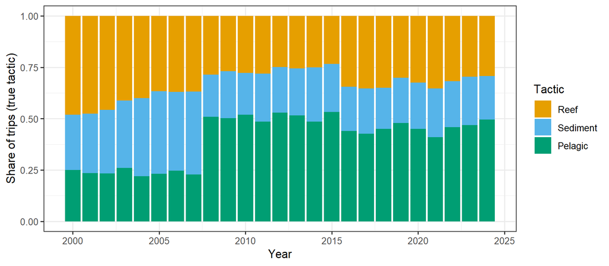

```r
sim$Plots$tactics
```

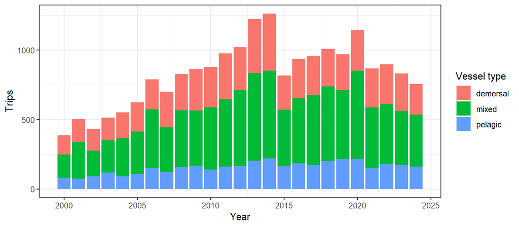

```r
sim$Plots$effort
```

The result is that nominal CPUE (orange) departs from the true biomass (black) in different ways for each species:

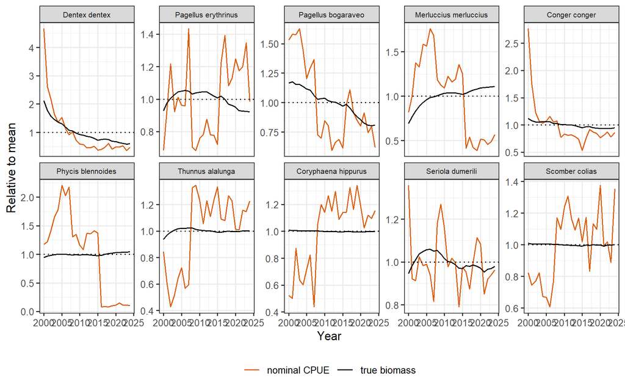

```r
sim$Plots$cpue
```

# 7. Reporting: from sets to a logbook

The logbook records **trips**, not sets. A share `logbook$two_sets` of trips (default 0.3) makes a second set, and with probability `logbook$switch_tactic` (default 0.7) the second set uses another tactic. The catches of both sets are summed into one record at the position of the first set, so these trips mix two catch compositions, as in many real logbooks.

```r
mixed <- !is.na(tr$tactic2) & tr$tactic2 != tr$tactic
mean(mixed)                                  # share of trips that mix tactics
```

```
## [1] 0.1783129
```

```r
round(tapply(mixed, tr$vessel_type, mean), 3)
```

```
## demersal    mixed  pelagic
##    0.216    0.207    0.038
```

Pelagic specialists make mixed trips only on their non-loyal trips. Further reporting settings:

| Setting | Default | Effect |
| --- | --- | --- |
| `obs_res` | 5 | positions reported as centres of 5 x 5 blocks |
| `missing_position` | 0.02 | share of trips without position |
| `round_to` | 0.5 | catches rounded to 0.5 kg |
| `underreport` | small catches (< 2 kg) of cheap species (price <= 3) | dropped with probability 0.5 |
| `synonyms`, `synonym_rate` | blackspot seabream | 10% recorded under its common name |

```r
head(sim$logbook, 8)
```

```
##   trip year month vessel hours  lon   lat               species    kg
## 1    1 2000     1    V04   7.3 3.85 36.85         Dentex dentex 256.5
## 2    1 2000     1    V04   7.3 3.85 36.85        Scomber colias  23.5
## 3    1 2000     1    V04   7.3 3.85 36.85      Seriola dumerili  14.0
## 4    2 2000     1    V12   9.7 3.85 36.85         Conger conger  83.5
## 5    2 2000     1    V12   9.7 3.85 36.85 Merluccius merluccius  24.5
## 6    2 2000     1    V12   9.7 3.85 36.85        Scomber colias   3.5
## 7    2 2000     1    V12   9.7 3.85 36.85      Seriola dumerili   9.5
## 8    3 2000     1    V10   7.8 4.85 39.35    Pagellus bogaraveo  30.5
```

# 8. Basic mechanics: what the PCs and clusters capture

We now take the logbook through the first steps of the toolbox and compare the targeting covariates with the truth.

```r
x <- cpue_data(sim$logbook, year = "year", species = "species", catch = "kg",
               effort = "hours", id = "trip", vessel = "vessel",
               lon = "lon", lat = "lat", covariates = "month",
               synonyms = c("Blackspot seabream" = "Pagellus bogaraveo"))
x <- subset(x, !is.na(lon), note = "positions reported")
x <- select_species(x, threshold = 0.95)
x <- add_targeting(x)
x$targeting$pca
```

```
## <cpue_pca> 19218 operations, 10 species, transform: fourth_root
##  PC eigenvalue share cumulative
##   1      2.192 0.219      0.219
##   2      1.707 0.171      0.390
##   3      1.340 0.134      0.524
##   4      1.108 0.111      0.635
##   5      1.056 0.106      0.740
##   6      0.792 0.079      0.820
##   7      0.569 0.057      0.876
##   8      0.530 0.053      0.929
## Optimal Coordinates: 3 non-trivial PC(s); 4 clusters by the npc + 1 rule
```

Attach the truth of each trip (never available in real data):

```r
truth <- sim$trips[match(x$data$trip, sim$trips$trip), ]
x$data$true_tactic <- truth$tactic
x$data$habitat <- ifelse(truth$tactic == "Pelagic", "pelagic", truth$habitat)
x$data$depth <- truth$depth
x$data$mixed <- ifelse(!is.na(truth$tactic2) & truth$tactic2 != truth$tactic,
                       "two tactics", "one tactic")
x$data$X <- truth$X
x$data$Y <- truth$Y
```

## PCs against tactic and habitat

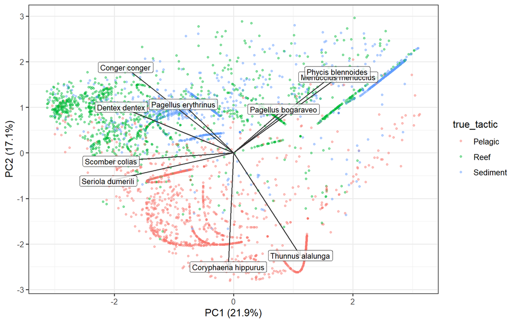

```r
plot_biplot(x, colour_by = "true_tactic")
```

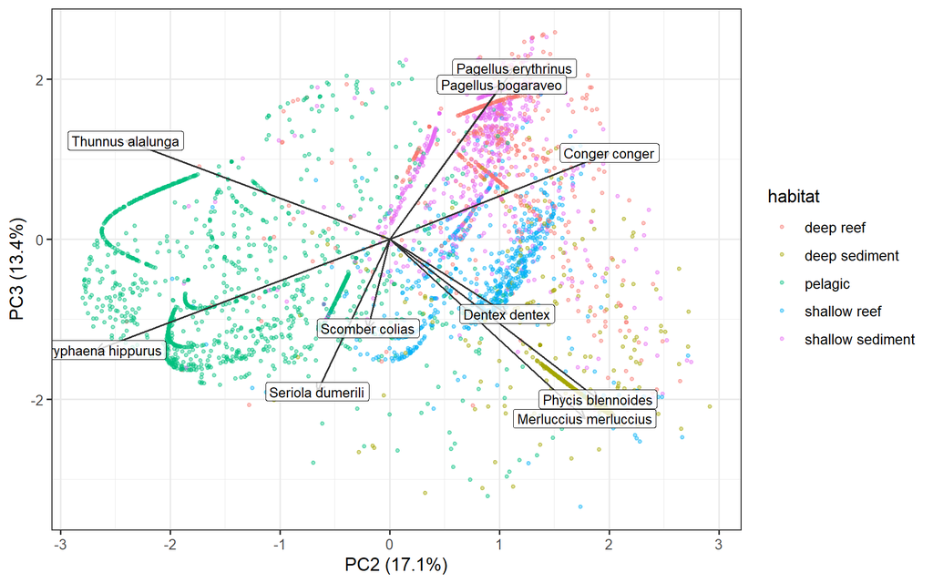

```r
plot_biplot(x, pcs = c(2, 3), colour_by = "habitat")
```

## PCs against depth and the true position

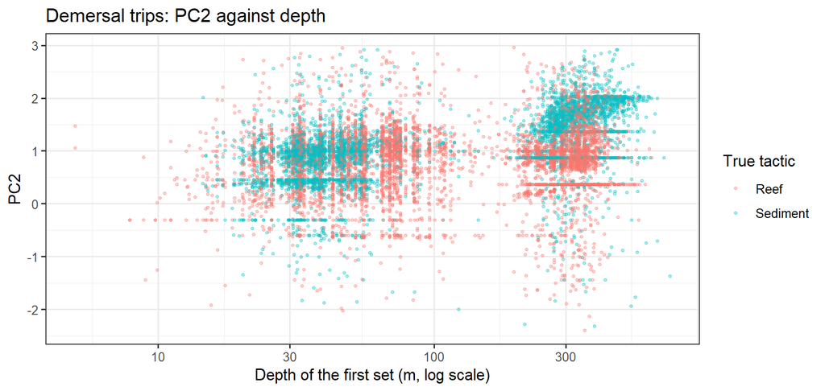

```r
demersal_trips <- x$data$true_tactic != "Pelagic"
ggplot(x$data[demersal_trips, ], aes(x = depth, y = PC2, colour = true_tactic)) +
  geom_point(alpha = 0.3, size = 0.7) + scale_x_log10() +
  labs(x = "Depth of the first set (m, log scale)", colour = "True tactic",
       title = "Demersal trips: PC2 against depth") + theme_bw()
```

If depth is carried by another PC in your run, replace `PC2` by that PC.

Averaged by the **true** cell, the PC scores map the habitat at a finer scale than the reported positions; the reported 5 x 5 blocks blur it.

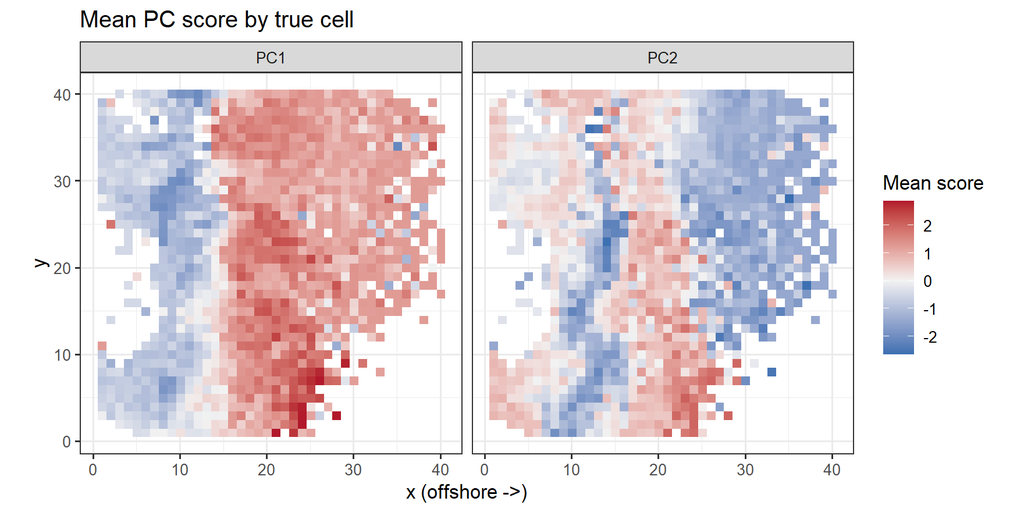

```r
cell_pc <- aggregate(cbind(PC1, PC2) ~ X + Y, data = x$data, FUN = mean)
pm <- rbind(data.frame(X = cell_pc$X, Y = cell_pc$Y, score = cell_pc$PC1, pc = "PC1"),
            data.frame(X = cell_pc$X, Y = cell_pc$Y, score = cell_pc$PC2, pc = "PC2"))
ggplot(pm, aes(x = X, y = Y, fill = score)) +
  geom_raster() + facet_wrap(~pc) + coord_equal() +
  scale_fill_gradient2(low = "#2166ac", mid = "grey95", high = "#b2182b") +
  labs(x = "x (offshore ->)", y = "y", fill = "Mean score",
       title = "Mean PC score by true cell") + theme_bw()
```

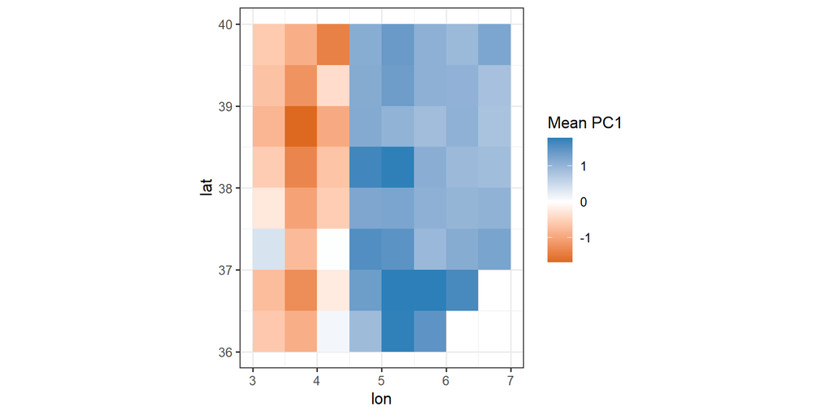

```r
plot_targeting(x, res = 0.5)$map_pc
```

## Mixed trips lie between the clusters

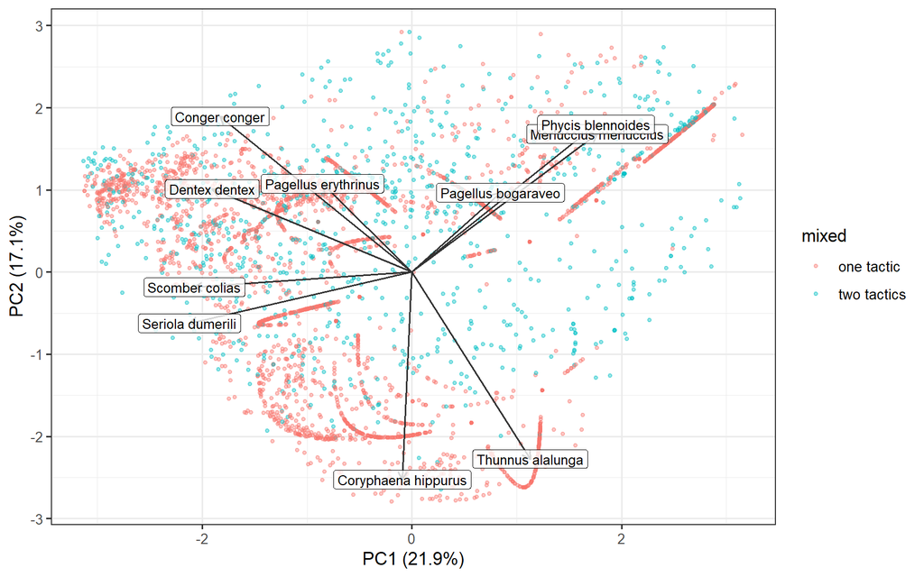

```r
plot_biplot(x, colour_by = "mixed")
```

Trips that combine two tactics have intermediate compositions. PCs place them continuously; clusters have to assign each to one tactic.

## Clusters against the true tactic

```r
tactic_table(x)
```

```
##   FT operations share              dominant Scomber colias Seriola dumerili
## 1  1       9936 0.517        Scomber colias           38.3             11.6
## 2  2       3620 0.188      Thunnus alalunga            2.2              1.9
## 3  3       2849 0.148    Pagellus bogaraveo            1.6              1.6
## 4  4       2813 0.146 Merluccius merluccius            2.4              1.6
##   Conger conger Thunnus alalunga Coryphaena hippurus Pagellus erythrinus
## 1          10.8              0.7                 8.8                15.4
## 2           1.1             79.6                10.1                 2.2
## 3           3.2              0.7                 2.0                 9.0
## 4           2.4              1.0                 1.1                 2.6
##   Pagellus bogaraveo Merluccius merluccius Phycis blennoides Dentex dentex
## 1                0.5                   0.5               0.2          13.1
## 2                0.6                   0.7               0.4           1.2
## 3               75.5                   1.6               0.7           4.0
## 4                2.1                  73.2              10.9           2.7
```

```r
round(prop.table(table(cluster = x$data$FT, tactic = x$data$true_tactic), 1), 2)
```

```
##        tactic
## cluster Pelagic Reef Sediment
##       1    0.43 0.33     0.24
##       2    0.96 0.02     0.02
##       3    0.05 0.85     0.10
##       4    0.07 0.16     0.78
```

```r
round(prop.table(table(cluster = x$data$FT, habitat = x$data$habitat), 1), 2)
```

```
##        habitat
## cluster deep reef deep sediment pelagic shallow reef shallow sediment
##       1      0.04          0.01    0.43         0.22             0.30
##       2      0.01          0.01    0.96         0.01             0.01
##       3      0.83          0.03    0.05         0.03             0.06
##       4      0.10          0.75    0.07         0.04             0.04
```

Clusters describe the catch composition, which reflects both the gear and where it was used, so they rarely match tactics one to one: mixed trips, gear overlap and neighbouring habitats blur the link.

## Targeting over time

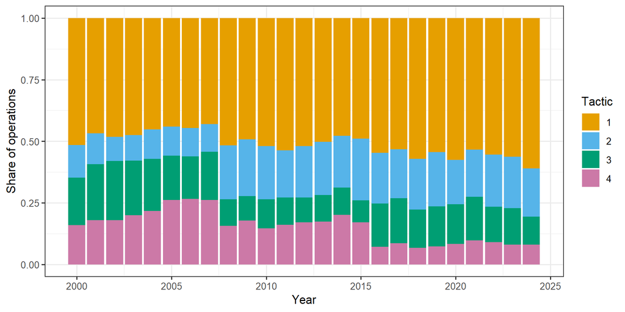

```r
pt <- plot_targeting(x, res = 0.5)
pt$time
```

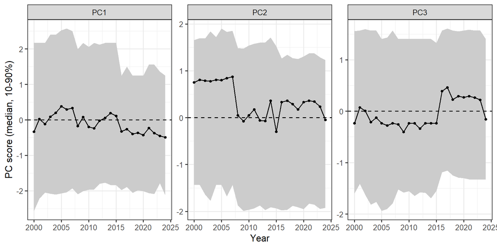

```r
pt$pcs_time
```

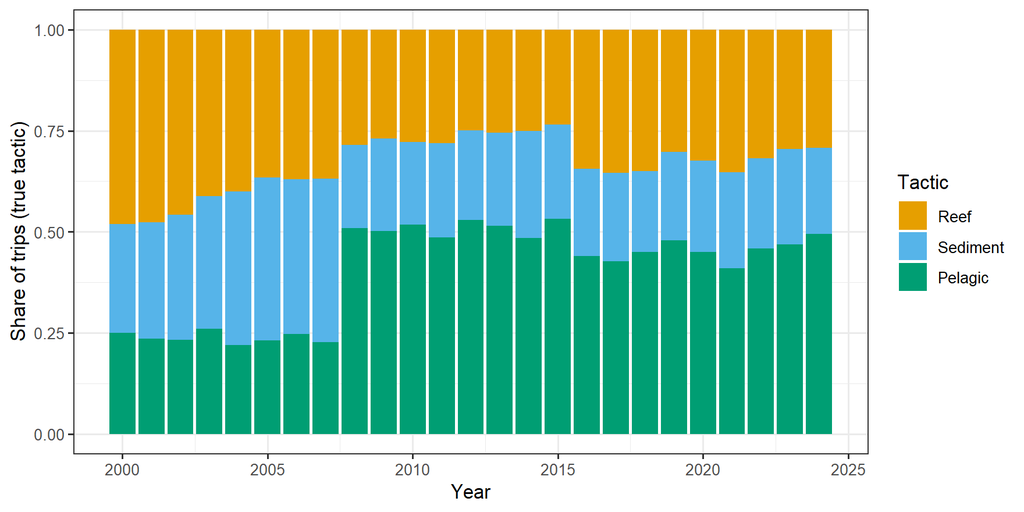

```r
sim$Plots$tactics
```

The clusters and PCs change in **steps** at the price changes (2008, 2016) and the closure (2016), as the true tactic shares do.

## Vessel profiles against the true vessel type

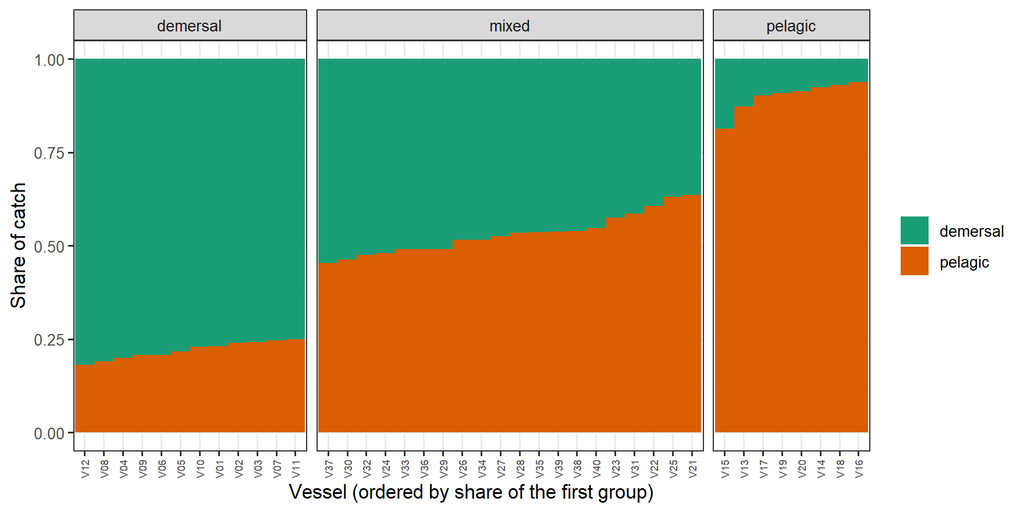

```r
groups <- split(sim$settings$species$species, sim$settings$species$group)
type <- tapply(sim$trips$vessel_type, sprintf("V%02d", sim$trips$vessel),
               function(z) z[1])
plot_vessel_profile(x, groups = groups, by = type)
```

Specialists sit at the ends (almost all demersal or almost all pelagic catch), mixed vessels in between. With loyalty 0.8 the specialists are clear but not pure, so rules on the catch of the target species (`select_vessels()`) recover them only approximately.

# Things to try

- **Reef patches:** `reef_scale = 1` against `6`, and compare `Base+S` with `DPC+S` in the standardisation: the gap shrinks as patches grow larger than the reporting blocks.
- **Loyalty:** `loyalty = c(demersal = 1, pelagic = 1, mixed = 0)` (strict specialists) or all zero (every vessel mixed).
- **Mixed trips:** `logbook = list(two_sets = 0)` (one set per trip) or `switch_tactic = 1`; see how the clusters separate and how the PC biplot changes.
- **Reporting:** `obs_res = 1` (exact positions) against 10 (very coarse).
- **Stock trends:** change `B_start` or `r` so that species trends diverge, and check whether the PCs start absorbing them (compare `n_pc`).

# References

Winker, H., Kerwath, S.E. and Attwood, C.G. (2014) Proof of concept for a novel procedure to standardize multispecies catch and effort data. Fisheries Research 155: 149-159.

Thorson, J.T., Fonner, R., Haltuch, M.A., Ono, K. and Winker, H. (2017) Accounting for spatiotemporal variation and fisher targeting when estimating abundance from multispecies fishery data. Canadian Journal of Fisheries and Aquatic Sciences 74: 1794-1807.